# Team 1 - Lab 5

Dynamic Linear Models (DLMs) - Time-varying productivity of salmon

Nicole, Tina, Lilac

May 24, 2025

# Data

The data are a dataframe with columns for brood year (`brood_year`), number of spawners (`spawners`), number of recruits (`recruits`) and PDO at year $t-2$ in summer (`pdo_summer_t2`) and in winter (`pdo_winter_t2`).

# General tasks

Use the information and data in the previous section to answer the following questions. Note that if any model is not converging, then you will need to increase the `maxit` parameter in the `control` argument/list that gets passed to `MARSS()`. For example, you might try `control=list(maxit=2000)`.

## Question 1: Reduced Ricker Model

$$\begin{align*}
\text{log}(R_t) &= \alpha_t + \text{log}(S_t) + v_t \\
\text{log}(R_t/S_t) &= \alpha_t + v_t
\end{align*}$$

This model assumes no density-dependent survival in that the number of recruits is an ascending function of spawners. Plot the ts of $\alpha_t$ and note the AICc for this model. Also plot appropriate model diagnostics.

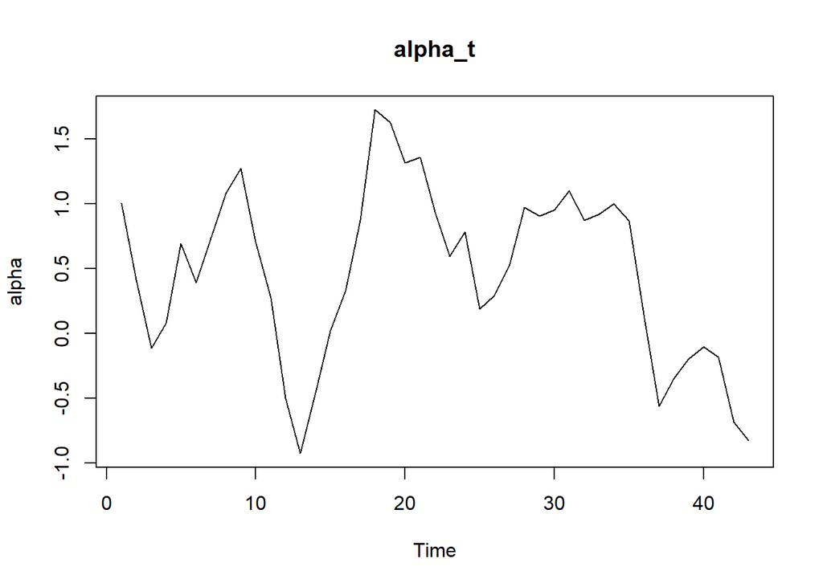

```
## [1] "Reduced Ricker AIC=" "110.358961836648"
```

[figure not shown]

.

The model diagnostics look fine. There doesn’t appear to be any patterns in the residual plots, autocorrelation in the ACF plots, and the QQ-plot shows some deviation from the line but not enough to be very concerned.

## Question 2: Full Ricker Model

Fit the full Ricker model with a time-varying intercept and a static effect of spawners. For this model, obtain the time series of $\alpha_t$, which is an estimate of the stock productivity in the absence of density-dependent effects. How do these estimates of productivity compare to those from the previous question? Plot the ts of $\alpha_t$ and note the AICc for this model. Also plot appropriate model diagnostics. ($Hint$: If you don’t want a parameter to vary with time, what does that say about its process variance?)

$$\begin{align*}
\text{log}(R_t/S_t) &= \alpha_t + \beta_t*\text{log}(S_t) + v_t \\
\end{align*}$$

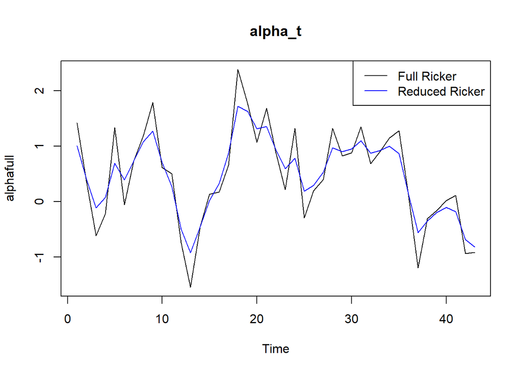

```r
alphafull<-fullricker$states[1,]
ts.plot(alphafull, main="alpha_t")
lines(alpha, col="blue")
legend("topright", legend=c("Full Ricker", "Reduced Ricker"), col=c("black", "blue"), lty=1)
```

```r
#print AIC
reducedaicc<-reducedricker$AICc
fullaicc<-fullricker$AICc
AICc<-cbind(model=c("Full Ricker", "Reduced Ricker"), AICc=c(fullaicc, reducedaicc))
print(AICc)
```

```
##      model            AICc
## [1,] "Full Ricker"    "309.642277947727"
## [2,] "Reduced Ricker" "110.358961836648"
```

```r
#plot diagnostics
pdf("marss_fullricker_plot.pdf", width = 7, height = 6)
plot(fullricker, silent = TRUE)
dev.off()
```

[figure not shown]

.

## Question 3: Summer PDO

Fit the expanded model that includes the summer PDO index as the covariate (`pdo_summer_t2`). What is the mean level of productivity? Plot the ts of $\delta_t$ and note the AICc for this model. Also plot appropriate model diagnostics.

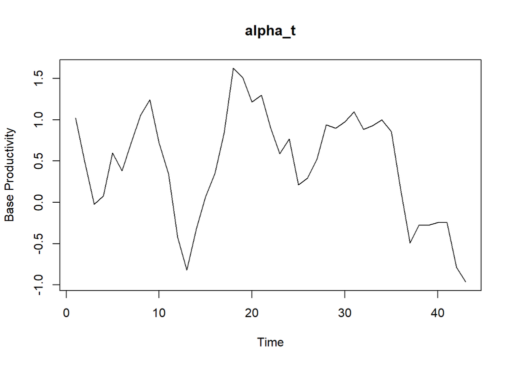

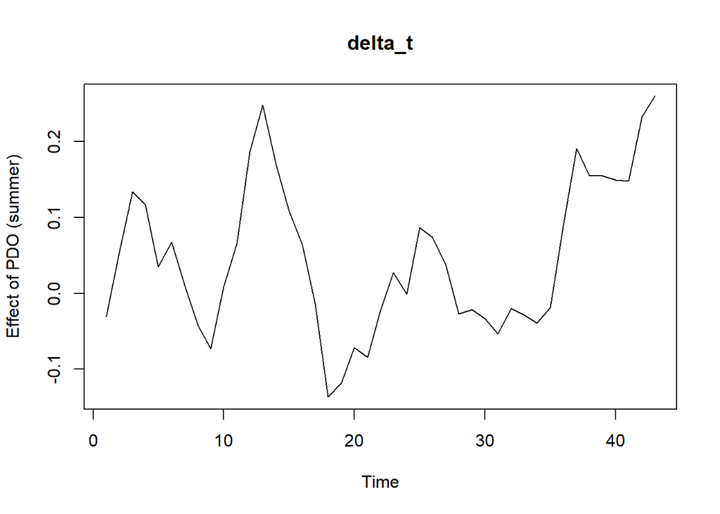

```
## Mean alpha_t (base productivity): 0.4589894
```

```
## AICc: 117.9028
```

```
## MARSSresiduals.tt1 reported warnings. See msg element of returned residuals object.
```

[figure not shown]

.

## Question 4: Winter PDO

Fit the expanded model that includes the winter PDO index as the covariate (`pdo_winter_t2`). What is the mean level of productivity? Plot the ts of $\delta_t$ and note the AICc for this model. Also plot appropriate model diagnostics.

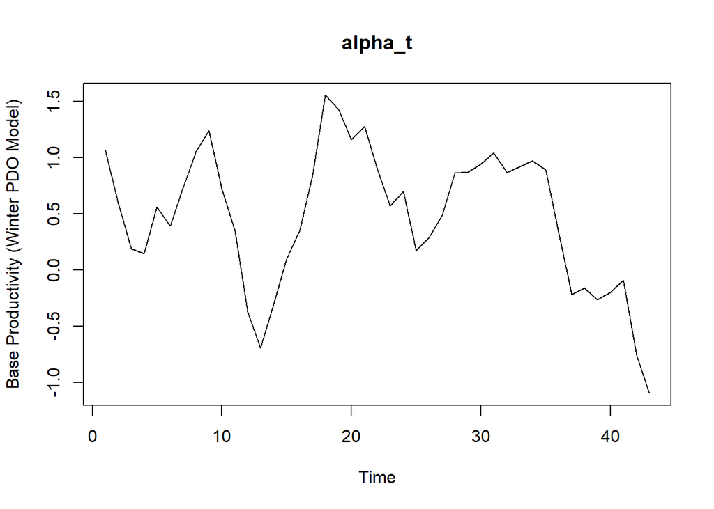

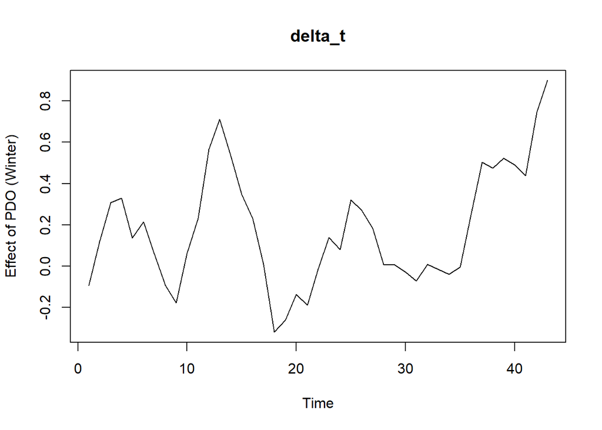

```
## Mean alpha_t (base productivity): 0.476922
```

```
## AICc for Winter PDO model: 112.7284
```

```
## MARSSresiduals.tt1 reported warnings. See msg element of returned residuals object.
```

[figure not shown]

.

The mean level of productivity for summer PDO model is $0.459$ and the mean level of productivity for winter PDO model is $0.477$, which represent the average log productivity of the sockeye salmon population in the absence of environmental effects. Mean base productivity ($\bar\alpha_t$) is slightly higher in the winter model, suggesting that once winter covariation is accounted for, the underlying stock productivity intercept is elevated.

The AICc for summer PDO model is $117.9$ and the AICc for winter PDO model is $112.7$. The Winter PDO model has a substantially lower AICc (ΔAICc ≈ 5.17), indicating it better balances fit and complexity.

Based on the model results, we recommend that habitat and hatchery managers might focus monitoring efforts on winter conditions like ice cover and plankton dynamics to anticipate recruitment anomalies.

## Question 5: PDO Covariate Comparison

Based on AICc, which of the models above is the most parsimonious? Is it well behaved (i.e., are the model assumptions met)? Plot the model forecasts for the best model. Is this a good forecast model?

```
##            Model     AICc
## 1 Reduced Ricker 110.3590
## 2    Full Ricker 309.6423
## 3     Summer PDO 117.9028
## 4     Winter PDO 112.7284
```

```
## Best model: Reduced Ricker
```

```
## Shapiro–Wilk test for residuals: W = 0.983 , p = 0.747
```

```
## Residuals not significantly non‐normal.
```

```
## Forecast plot saved to 'best_model_forecast.pdf'
```

[figure not shown]

Surprisingly that we found the reduced Ricker model, which is the simple random‐walk intercept model without density dependence or environmental covariates had the lowest AICc among the four candidates. This indicates that, for these data, neither spawner density nor seasonal PDO indices improve parsimony enough to justify their additional parameters.

Based on the residual diagnostics, there is no obvious residual patterns over time, no significant autocorrelation in the ACF, and an approximately linear QQ‐plot. A Shapiro–Wilk test on the model residuals returned W = 0.983, p = 0.747, indicating no significant departure from normality. These diagnostics suggest that the Reduced Ricker model is well behaved and meets the key Gaussian-state‐space assumptions of MARSS.

Generally speaking, it is a good forecast model because it is parsimonious and statistically well behaved—residuals are white noise and approximately normal, but it is also important to note that the forecasts are based on the assumption that the underlying process remains stable over the forecast horizon. The model does not account for potential future changes in environmental conditions or other factors that could affect salmon productivity. It has the limitation of Lacking any mechanism (covariates or density feedback) to predict genuine ups or downs in productivity. Therefore, while the model provides a reasonable forecast based on historical data, it may not capture future dynamics if significant environmental shifts occur.

## Question 6: Alternative co-variates

Consider other environmental factors that could influence the time-varying intrinsic productivity of these salmon. For example, are there other large-scale indices of ocean conditions (e.g., sea-surface temperature, El Niño Southern Oscillation)? You could also consider the possible influence of other salmon stocks such as those we examined in Lab 1.

We will fit a model to the Kvichak sockeye data that considers annual abundance of chinook stocks from lab 1 as a covariate.

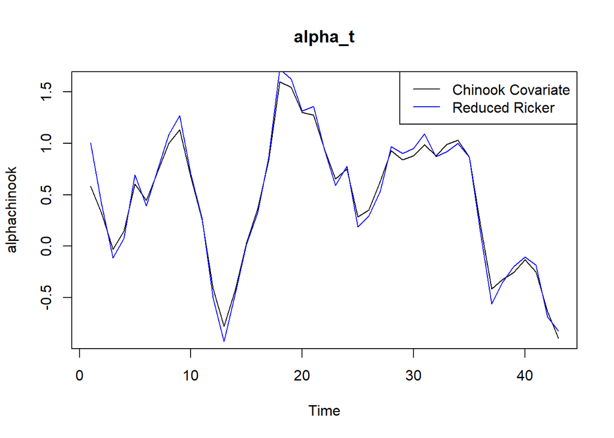

```
##      model               AICc
## [1,] "Chinook covariate" "111.39454710748"
## [2,] "Reduced Ricker"    "110.358961836648"
```

[figure not shown]

.

# Team contributions

Nicole fit and interpreted the reduced and full Ricker models in questions 1 and 2, and the chinook covariate models in question 6. Lilac completed code and interpretation in question 3. Tina completed codes and interpretation for question 4 and 5, and expanded the discussion from question 3.